# solution

```python
import pandas as pd
import matplotlib.pyplot as plt
import matplotlib.dates as mdates
import datetime
import gc
import numpy as np
from typing import Any, Dict
import seaborn as sns
import dask.dataframe as dd
```

## 0. Data Preparation

### 0.1. Loading datasets

```python
adds_new_client_df = pd.read_csv('adds_new_client.csv')
exports_note_df = pd.read_csv('exports_note.csv')
new_registration_df = pd.read_csv('new_registration.csv')
signs_notes_df = pd.read_csv('signs_notes.csv')
stripe_charges_df = pd.read_csv('stripe_charges.csv')
uploads_audio_file_df = pd.read_csv('uploads_audio_flle.csv')
```

### 0.2. Convert timestamps to datetime

```python
adds_new_client_df['time'] = pd.to_datetime(adds_new_client_df['time'], unit='s')
exports_note_df['time'] = pd.to_datetime(new_registration_df['time'], unit='s')
new_registration_df['time'] = pd.to_datetime(new_registration_df['time'], unit='s')
signs_notes_df['time'] = pd.to_datetime(new_registration_df['time'], unit='s')
stripe_charges_df['time'] = pd.to_datetime(new_registration_df['time'], unit='s')
uploads_audio_file_df['time'] = pd.to_datetime(new_registration_df['time'], unit='s')
```

### 0.3. Replace 'null' values with 0 in specific columns

```python
signs_notes_df['noteLength'] = signs_notes_df['noteLength'].fillna(0)
signs_notes_df['editDistance'] = signs_notes_df['editDistance'].fillna(0)
signs_notes_df['editPercentage'] = signs_notes_df['editPercentage'].fillna(0)
```

### 0.4. Rename 'time' columns in each dataframe to avoid potential merge errors

```python
adds_new_client_df.rename(columns={'time': 'adds_new_client_time'}, inplace=True)
exports_note_df.rename(columns={'time': 'exports_note_time'}, inplace=True)
new_registration_df.rename(columns={'time': 'new_registration_time'}, inplace=True)
signs_notes_df.rename(columns={'time': 'signs_notes_time'}, inplace=True)
stripe_charges_df.rename(columns={'time': 'stripe_charges_time'}, inplace=True)
uploads_audio_file_df.rename(columns={'time': 'uploads_audio_file_time'}, inplace=True)
```

```python
adds_new_client_df.rename(columns={'event': 'adds_new_client_event'}, inplace=True)
exports_note_df.rename(columns={'event': 'exports_note_event'}, inplace=True)
new_registration_df.rename(columns={'event': 'new_registration_event'}, inplace=True)
signs_notes_df.rename(columns={'event': 'signs_notes_event'}, inplace=True)
stripe_charges_df.rename(columns={'event': 'stripe_charges_event'}, inplace=True)
uploads_audio_file_df.rename(columns={'event': 'uploads_audio_file_event'}, inplace=True)
```

# 1. User Acquisition and Engagement:

## 1.1. Yearly New Registrations

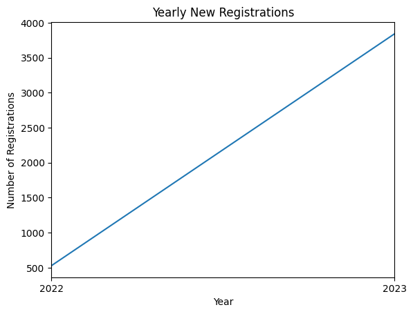

```python
new_registrations_monthly = new_registration_df.resample('Y', on='new_registration_time').size()
new_registrations_monthly.plot(title='Yearly New Registrations')
plt.ylabel('Number of Registrations')
plt.xlabel('Year')
plt.show()
```

### Code Explanation:

The code resamples the data on an annual basis to count new user registrations per year. It then plots these counts over time.

### Analysis:

The trend in Yearly New Registrations shows a positive growth in user acquisition. An upward trend indicates increasing interest and successful acquisition strategies over the given period.

## 1.2. Monthly New Registrations

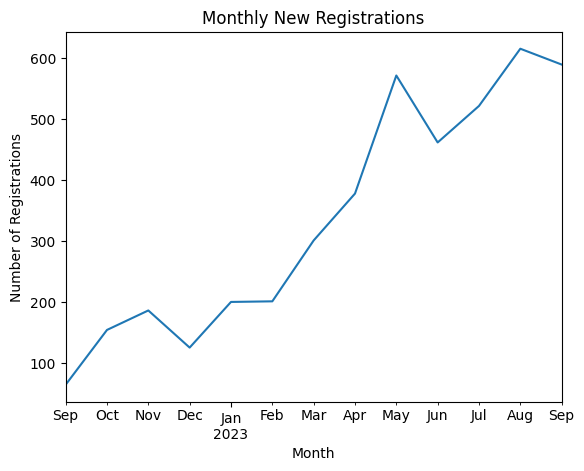

```python
new_registrations_monthly = new_registration_df.resample('M', on='new_registration_time').size()
new_registrations_monthly.plot(title='Monthly New Registrations')
plt.ylabel('Number of Registrations')
plt.xlabel('Month')
plt.show()
```

### Code Explanation:

This code resamples the data on a monthly basis and plots the number of new user registrations for each month.

### Analysis:

The Monthly New Registrations chart generally shows an increasing trend with some fluctuations, suggesting seasonality or variability in monthly marketing efforts or user interest. Peaks and troughs could also indicate the effects of specific campaigns or external factors influencing user sign-ups.

## 1.3. Weekly New Registrations

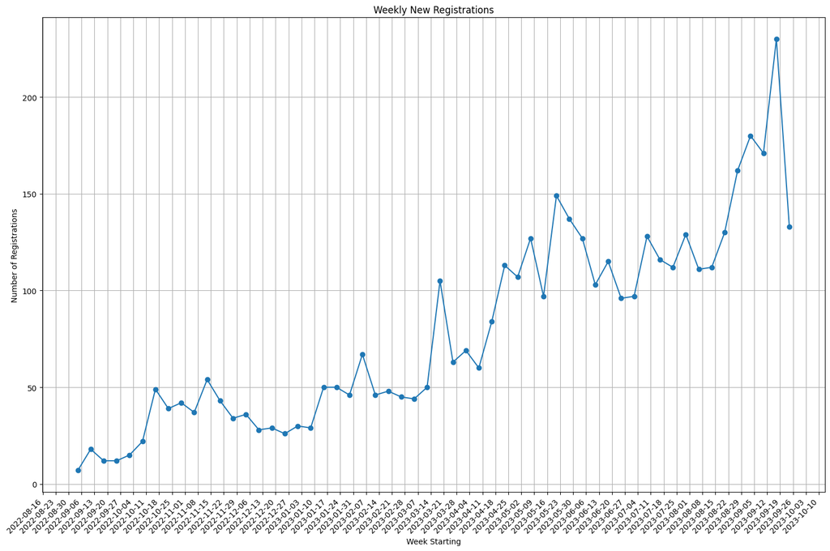

```python
new_registrations_weekly = new_registration_df.resample('W', on='new_registration_time').size()

plt.figure(figsize=(15, 10))
plt.plot(new_registrations_weekly.index, new_registrations_weekly, marker='o', linestyle='-')

plt.title('Weekly New Registrations')
plt.ylabel('Number of Registrations')
plt.xlabel('Week Starting')

plt.gca().xaxis.set_major_formatter(mdates.DateFormatter('%Y-%m-%d'))
plt.gca().xaxis.set_major_locator(mdates.WeekdayLocator())

plt.xticks(rotation=45, ha='right')

plt.tight_layout()
plt.grid(True)
plt.show()
```

### Code Explanation:

This code resamples the data weekly and plots a line graph of new user registrations each week, which can give insights into weekly trends and anomalies.

### Analysis:

Weekly New Registrations demonstrate more granularity in the data, showing weekly fluctuations in user registration numbers. Spikes might correspond to marketing campaigns or events, while dips could represent periods of lower activity.

## 1.4. Weekly Growth Rate in New Registrations

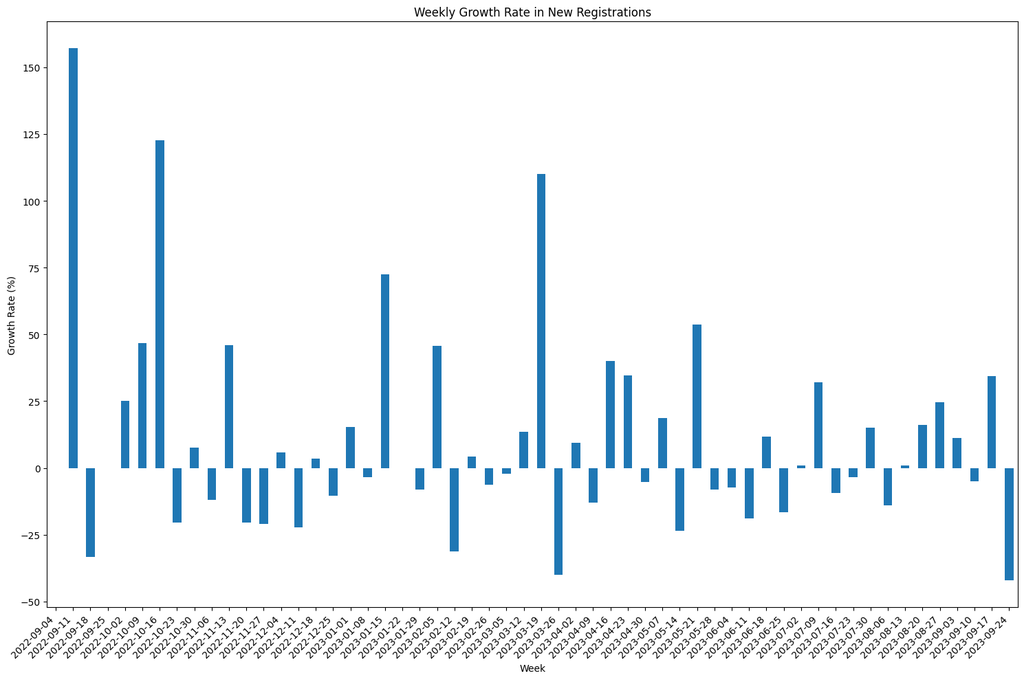

```python
new_registrations_weekly = new_registration_df.resample('W', on='new_registration_time').size()
weekly_growth_rate = new_registrations_weekly.pct_change() * 100

plt.figure(figsize=(15, 10))
weekly_growth_rate.plot(kind='bar')
plt.title('Weekly Growth Rate in New Registrations')
plt.ylabel('Growth Rate (%)')
plt.xlabel('Week')

xticks_labels = [item.strftime('%Y-%m-%d') for item in weekly_growth_rate.index]
plt.xticks(ticks=range(len(xticks_labels)), labels=xticks_labels, rotation=45, ha="right")

plt.tight_layout()
plt.show()
```

### Code Explanation:

Calculates the percentage change in new registrations week over week, providing insights into the growth rate's consistency.

### Analysis:

The Weekly Growth Rate in New Registrations bar chart illustrates the volatility in growth, with some weeks showing significant increases and others showing decreases. This could be influenced by various factors like marketing activities, platform changes, or external events.

## 1.5. Frequency Distributions

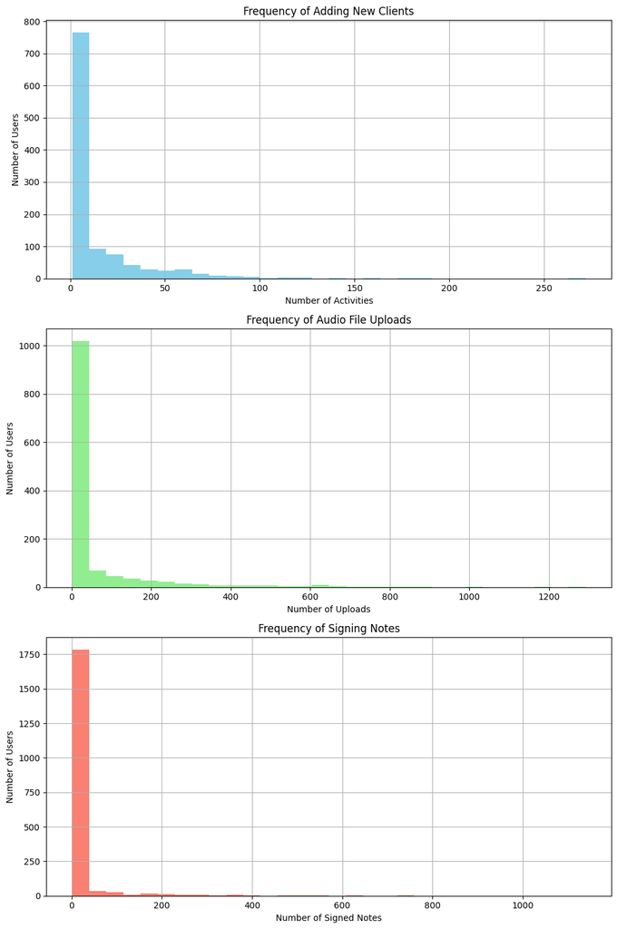

```python
adds_new_client_freq = adds_new_client_df.groupby('userId').size()
audio_uploads_freq = uploads_audio_file_df.groupby('userId').size()
signs_notes_freq = signs_notes_df[signs_notes_df['noteLength'] > 0].groupby('userId').size()

fig, axs = plt.subplots(3, 1, figsize=(10, 15))

adds_new_client_freq.hist(bins=30, ax=axs[0], color='skyblue')
axs[0].set_title('Frequency of Adding New Clients')
axs[0].set_xlabel('Number of Activities')
axs[0].set_ylabel('Number of Users')

audio_uploads_freq.hist(bins=30, ax=axs[1], color='lightgreen')
axs[1].set_title('Frequency of Audio File Uploads')
axs[1].set_xlabel('Number of Uploads')
axs[1].set_ylabel('Number of Users')

signs_notes_freq.hist(bins=30, ax=axs[2], color='salmon')
axs[2].set_title('Frequency of Signing Notes')
axs[2].set_xlabel('Number of Signed Notes')
axs[2].set_ylabel('Number of Users')

plt.tight_layout()
plt.show()
```

### Code Explanation:

The code generates histograms for three types of user activities: adding new clients, uploading audio files, and signing notes. It displays the distribution of these activities across all users.

### Analysis:

- **Adding New Clients**: Most users add a few clients, with a steep drop-off as the number increases, suggesting a large number of less active users.
- **Audio File Uploads**: There's a very high number of users with a low number of uploads, indicating a potential issue in engaging users to upload content.
- **Signing Notes**: Similar to the clients added, most users sign a few notes, and the frequency decreases sharply as the number of signed notes increases.

## 1.6. Unique Active Days per User

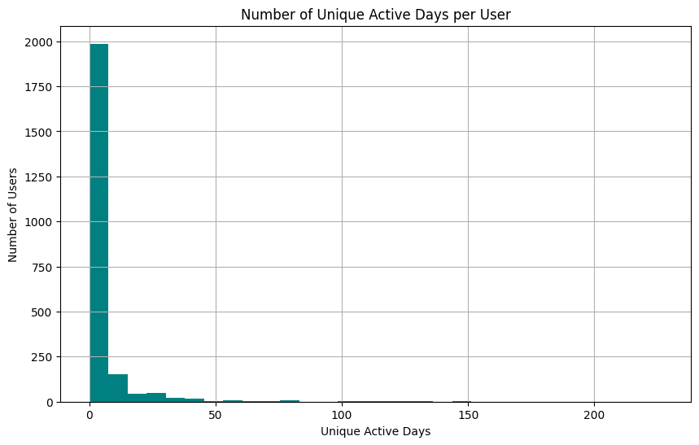

```python
all_activity_times = pd.concat([
    adds_new_client_df[['userId', 'adds_new_client_time']].rename(columns={'adds_new_client_time': 'activity_time'}),
    uploads_audio_file_df[['userId', 'uploads_audio_file_time']].rename(columns={'uploads_audio_file_time': 'activity_time'}),
    signs_notes_df[['userId', 'signs_notes_time']].rename(columns={'signs_notes_time': 'activity_time'}),
    exports_note_df[['userId', 'exports_note_time']].rename(columns={'exports_note_time': 'activity_time'})
], ignore_index=True)

all_activity_times['activity_time'] = pd.to_datetime(all_activity_times['activity_time'])

all_activity_times['activity_date'] = all_activity_times['activity_time'].dt.date
unique_active_days = all_activity_times.groupby('userId')['activity_date'].nunique()

plt.figure(figsize=(10, 6))
unique_active_days.hist(bins=30, color='teal')
plt.title('Number of Unique Active Days per User')
plt.xlabel('Unique Active Days')
plt.ylabel('Number of Users')
plt.show()
```

### Code Explanation:

This code combines activity data from different actions, calculates the number of unique days each user was active, and plots this as a histogram.

### Analysis:

The Number of Unique Active Days per User histogram shows that a vast majority of users are active for a relatively small number of days. This suggests that while user acquisition might be successful, user retention and long-term engagement may be areas needing improvement.

## Summary

### User Acquisition Trends

The data reveals a positive trajectory in user acquisition. Yearly and monthly registration data show a general upward trend, indicating effective strategies in attracting new users. Weekly data presents regular fluctuations, which may be attributed to specific marketing campaigns, seasonal effects, or external events impacting user sign-ups.

**Insight**: While user acquisition is growing, the rate of growth is inconsistent. This inconsistency can be addressed by analyzing which campaigns or periods yielded the best results and replicating these conditions.

**Recommendation**: Investigate the causes behind peak registration periods to understand what drives user sign-ups and apply these learnings to future strategies. Additionally, consider implementing referral programs or community-building initiatives to maintain momentum in growth.

### User Engagement Patterns

User engagement, as measured by activities like adding new clients, uploading audio files, and signing notes, varies greatly. The histograms show that a majority of users engage in these activities infrequently.

**Insight**: A significant number of users demonstrate low engagement levels post-registration. This suggests that while the platform is successful in attracting users, it faces challenges in retaining them and encouraging active participation.

**Recommendation**: Develop engagement strategies that encourage users to perform key actions more regularly. Gamification elements, improved user onboarding, regular content updates, or personalized outreach may enhance user engagement.

# 2. Content Quality and User Feedback:

## 2.1. User Engagement with Signed Notes

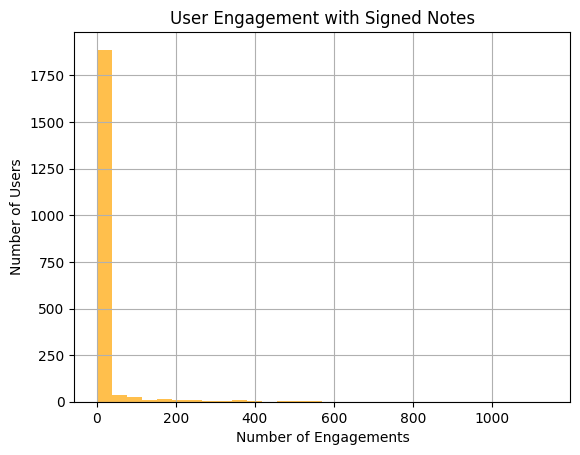

```python
signs_notes_engagement = signs_notes_df.groupby('userId').size()
signs_notes_engagement.hist(bins=30, color='orange', alpha=0.7)
plt.title('User Engagement with Signed Notes')
plt.xlabel('Number of Engagements')
plt.ylabel('Number of Users')
plt.show()
```

### Code Explanation:

This code section generates a histogram that visualizes the distribution of the number of engagements users have with signed notes. The graph shows a skewed distribution with a majority of users having very few engagements and very few users having a high number of engagements.

### Analysis:

- cHigh engagement is limited to a small group of users.
- The steep drop-off suggests that most users engage with the signing feature infrequently.
- Potential insight could be that the feature is not universally needed or it could be too complex or not well integrated into the user workflow.

## 2.2. Average Note Length Distribution

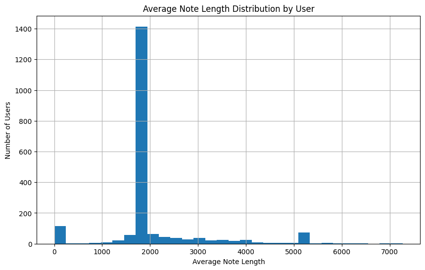

```python
average_note_length = signs_notes_df.groupby('userId')['noteLength'].mean()

plt.figure(figsize=(10, 6))
average_note_length.hist(bins=30)
plt.title('Average Note Length Distribution by User')
plt.xlabel('Average Note Length')
plt.ylabel('Number of Users')
plt.show()
```

### Code Explanation:

This section generates a histogram that shows the average note length per user. It reveals that most users have an average note length of around 2,000 characters, with few users having significantly longer or shorter notes.

### Analysis:

A large concentration of users with similar note lengths could indicate a common use case or template for notes. Users with extremely long or short notes might represent different use cases or outliers in data, such as test accounts or users with unique needs.

## 2.3. Correlation Matrix for Note Properties

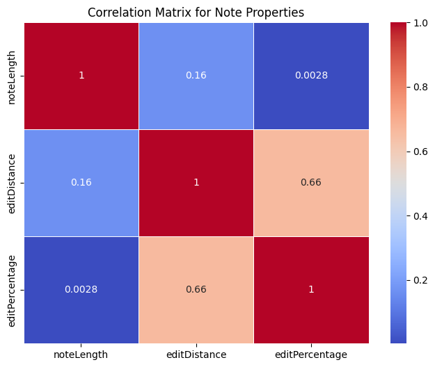

```python
correlation_matrix = signs_notes_df[['noteLength', 'editDistance', 'editPercentage']].corr()

plt.figure(figsize=(8, 6))
sns.heatmap(correlation_matrix, annot=True, cmap='coolwarm', linewidths=.5)
plt.title('Correlation Matrix for Note Properties')
plt.show()
```

### Code Explanation:

This section generates a heatmap that provides a visual representation of the correlation between note properties: note length, edit distance, and edit percentage.

### Analysis:

- Low correlation between note length and edit distance (0.16), and an even weaker correlation between note length and edit percentage (0.0028) suggests that longer notes don't necessarily correlate with a higher number of edits or a higher percentage of the note being edited.
- Moderate correlation between edit distance and edit percentage (0.66) indicates that as more edits are made, they tend to constitute a larger percentage of the note, which is expected as both metrics are measures of change.

## 2.4. Insights about the Quality of Auto-Generated Notes

```python
def analyze_auto_generated_notes(data: pd.DataFrame) -> Dict[str, Any]:

    insights = {}
    insights['unique_users'] = data['userId'].nunique()
    insights['average_note_length'] = data['noteLength'].dropna().mean()

    insights['percentage_notes_edited'] = 100 * data['editDistance'].notnull().mean()
    edited_notes = data[data['editDistance'].notnull()]
    insights['average_edit_distance'] = edited_notes['editDistance'].mean()
    insights['average_edit_percentage'] = edited_notes['editPercentage'].mean()

    insights['potential_data_issues'] = data.isnull().any().tolist()

    return insights

analyze_auto_generated_notes(signs_notes_df)
```

```
{'unique_users': 2040,
 'average_note_length': 2851.9934153877325,
 'percentage_notes_edited': 100.0,
 'average_edit_distance': 92.20095730132199,
 'average_edit_percentage': 3.1817862486228283,
 'potential_data_issues': [False, True, False, False, False, False]}
```

### Code Explanation:

This function aggregates different metrics from the signs_notes_df to provide insights into user behavior and note quality.

### Recommendations:

- Investigate the high engagement user group for insights into product strengths and potential advocacy.
- Explore reasons for edits in auto-generated notes to improve initial quality.
- Consider user segmentation and targeted feature education to increase engagement across the wider user base.
- Leverage the timing of marketing and user acquisition efforts to align with high registration periods for maximum impact.
- Regularly review weekly and monthly registration data to quickly identify and respond to negative trends.

## 3. Monetization and User Conversion

### 3.1. Distribution of Stripe Charges

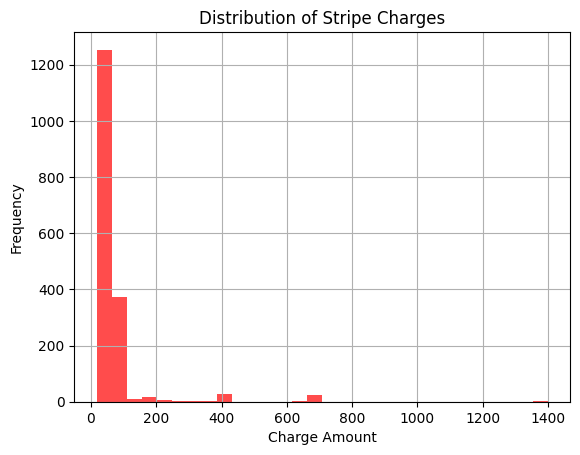

```python
stripe_charges_distribution = stripe_charges_df['amount'].hist(bins=30, color='red', alpha=0.7)
plt.title('Distribution of Stripe Charges')
plt.xlabel('Charge Amount')
plt.ylabel('Frequency')
plt.show()
```

### Code Explanation:

- The code snippet creates a histogram to display how often each charge amount occurs within the dataset.
- The color 'red' and transparency level 'alpha=0.7' are used for visualization clarity.

### Analysis:

- The histogram likely shows a high concentration of charges at lower amounts, with fewer instances of high charge amounts.
- This could indicate that lower-cost plans are more popular or that there are more one-time purchases as opposed to high-value transactions.

### 3.2. Upgrade Plan Distribution

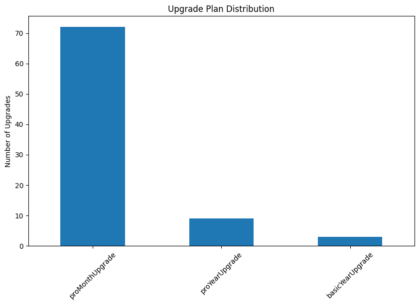

```python
upgrade_counts = stripe_charges_df[['proMonthUpgrade', 'proYearUpgrade', 'basicYearUpgrade']].sum()

plt.figure(figsize=(10, 6))
upgrade_counts.plot(kind='bar')
plt.title('Upgrade Plan Distribution')
plt.ylabel('Number of Upgrades')
plt.xticks(rotation=45)
plt.show()
```

### Code Explanation:

- The code snippet sums the occurrences of each upgrade type and then plots them in a bar chart.
- The x-axis represents the types of upgrades, and the y-axis represents the number of upgrades.

### Analysis:

- From the chart, you can deduce which upgrade plans are most popular.
- A trend in user preference for monthly versus yearly plans, or for pro upgrades versus basic upgrades, can be identified.

### 3.3. Upgrade Propensity by User

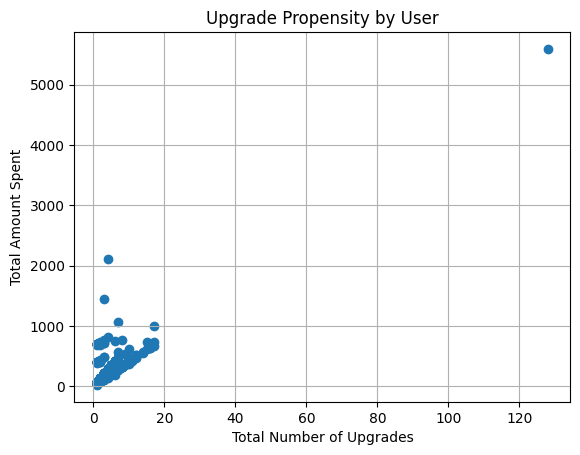

| userId | upgradeCount | totalSpend |
| --- | --- | --- |
| 0025e07f-bdaf-42bb-9606-4c470eb789c8 | 1 | 59.99 |
| 00e3462d-b577-4d84-93ec-a0cda70de8f9 | 1 | 39.99 |
| 01257313-4a47-4e8a-9e85-0733e7bd1f7b | 1 | 39.99 |
| 02c452a1-5cdb-456d-84d9-7faf326d5241 | 1 | 36.00 |
| 03591606-0f7f-42ff-944c-c5818a666a41 | 3 | 119.97 |
| ... | ... | ... |
| fc92079e-8baf-4101-ad8b-785a3ef1fced | 5 | 349.95 |
| fded9be5-c919-4c34-b633-5924464b7ab1 | 1 | 39.99 |
| ff4ec185-24e4-4330-b58d-ff87128d3a96 | 6 | 419.94 |
| ff8041b2-bc33-4718-934e-0e93165ead81 | 1 | 699.90 |
| fff4e952-a3fb-4b88-82f2-c78b2622ceb9 | 1 | 699.90 |

459 rows × 2 columns

```python
def visualize_upgrade_propensity(df):
    upgrade_columns = ['proMonthUpgrade', 'proYearUpgrade', 'monthPro', 'yearPro', 'basicYearUpgrade', 'monthBasic', 'yearBasic']
    df['totalUpgrades'] = df[upgrade_columns].sum(axis=1)

    upgrade_counts = df.groupby('userId')['totalUpgrades'].sum()
    spend_per_user = df.groupby('userId')['amount'].sum()

    upgrade_spend_df = pd.concat([upgrade_counts, spend_per_user], axis=1)
    upgrade_spend_df.columns = ['upgradeCount', 'totalSpend']

    plt.scatter(upgrade_spend_df['upgradeCount'], upgrade_spend_df['totalSpend'])
    plt.title('Upgrade Propensity by User')
    plt.xlabel('Total Number of Upgrades')
    plt.ylabel('Total Amount Spent')
    plt.grid(True)
    plt.show()

    return upgrade_spend_df

visualized_data = visualize_upgrade_propensity(stripe_charges_df)
visualized_data
```

### Code Explanation:

- The code aggregates data to calculate the total number of upgrades and the total amount spent per user.
- It then creates a scatter plot with the total number of upgrades on the x-axis and the total amount spent on the y-axis.

### Analysis:

- By observing clusters or patterns in the scatter plot, we can identify segments of users who are more likely to upgrade.
- We can infer whether spending more is correlated with a higher number of upgrades.

### Overall Analysis:

#### User Conversion Insights:

- The scatter plot can help identify if there are power users who contribute a disproportionate amount of revenue through repeated upgrades.
- It may also highlight if there is a ceiling effect where past a certain spend amount, users do not further upgrade, possibly indicating the highest-tier plan reached.

#### Recommendations:

- Given the popularity of lower-cost plans, consider creating promotional campaigns to encourage users to trial higher-tier plans.
- For users showing higher upgrade propensity, personalized incentives could be offered to maintain or increase their engagement and investment in the service.
- Investigate the needs of users who are spending more without increasing their upgrade count, as they might require more tailored services or plans.

#### Future Analysis:

- A cohort analysis could further segment users based on their first purchase date to track changes in behavior over time.
- A deeper dive into user demographics might reveal more about the segments who prefer different types of plans and their potential lifetime value.
- A/B testing different pricing strategies could optimize the balance between user acquisition and revenue.

# 4. User Retention and Churn:

### 4.1. Churned Users Calculation

```python
last_action_per_user = adds_new_client_df.groupby('userId')['adds_new_client_time'].max()
cutoff_date = pd.Timestamp('today') - pd.Timedelta(days=365)
churned_users = last_action_per_user[last_action_per_user < cutoff_date].index
print(f"Churned Users: {len(churned_users)}")
```

```
Churned Users: 191
```

### Code Explanation:

- It calculates the last action date per user from the adds_new_client_df.
- Users whose last action was more than 365 days from the current date are considered churned.
- It prints the number of churned users.

## 4.2. Calculate Churn Rate

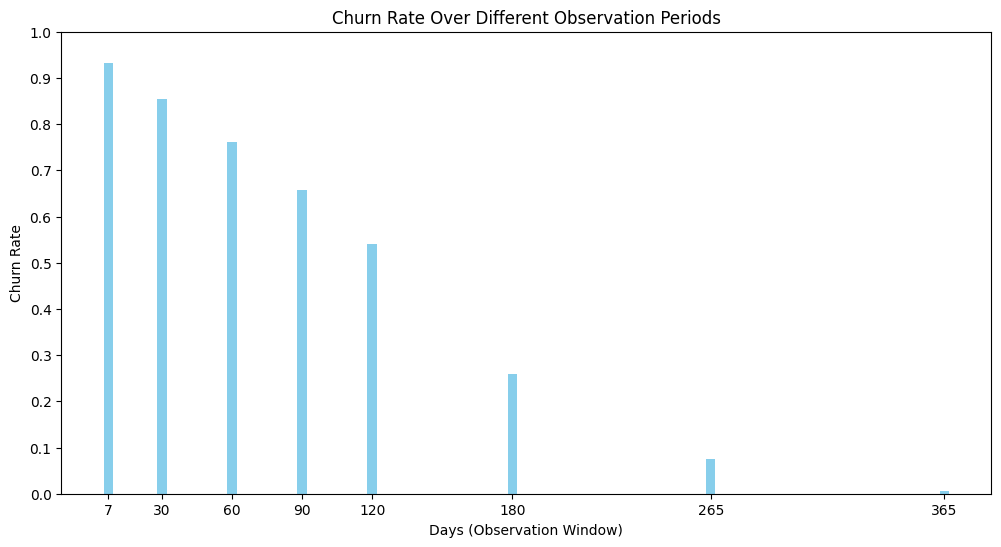

```
{7: 0.9328739152628892,
 30: 0.8537819415668259,
 60: 0.7608773984325736,
 90: 0.657523346245083,
 120: 0.5411824760532085,
 180: 0.2583250758189953,
 265: 0.07562381767408341,
 365: 0.0065909978080052846}
```

```python
def calculate_churn_rate(stripe_charges_df, adds_new_client_df, days):

    merged_df = pd.merge(stripe_charges_df, adds_new_client_df, on='userId', how='outer', suffixes=('_stripe_charge', '_client_add'))

    observation_window = pd.Timedelta(days=days)
    cutoff_date = max(merged_df['stripe_charges_time'].max(), merged_df['adds_new_client_time'].max()) - observation_window

    merged_df['churned'] = (merged_df['stripe_charges_time'] < cutoff_date) & (merged_df['adds_new_client_time'] < cutoff_date)

    churn_rate = merged_df['churned'].mean()

    return churn_rate

def visualize_churn_over_periods(stripe_charges_df, adds_new_client_df, periods):
    churn_rates = {}

    for days in periods:
        churn_rate = calculate_churn_rate(stripe_charges_df, adds_new_client_df, days)
        churn_rates[days] = churn_rate

    plt.figure(figsize=(12, 6))
    plt.bar(churn_rates.keys(), churn_rates.values(), color='skyblue', width=4)
    plt.xlabel('Days (Observation Window)')
    plt.ylabel('Churn Rate')
    plt.title('Churn Rate Over Different Observation Periods')
    plt.xticks(list(churn_rates.keys()))
    plt.yticks([i/10 for i in range(0, int(max(churn_rates.values())*10)+2)])
    plt.show()

    return churn_rates

periods_to_visualize = [7, 30, 60, 90, 120, 180, 265, 365]
churn_rates = visualize_churn_over_periods(stripe_charges_df, adds_new_client_df, periods_to_visualize)
churn_rates
```

### Code Explanation:

- It merges stripe_charges_df and adds_new_client_df by userId.
- Calculates whether a user has churned based on their last payment or client add action falling before the cutoff date determined by the observation window.
- Returns the mean churn rate over the observation window.
- Calls the previously defined calculate_churn_rate function for a list of observation window lengths.
- Creates a bar chart to visualize how churn rates differ over these varying periods.

### Analysis:

- By iterating over different observation windows, it is possible to see how churn rate changes as the window lengthens.
- The churn rates decrease as the observation window lengthens, which is expected since the longer the window, the more chance a user has to re-engage.
- The churn rates are particularly high in the short term, suggesting that user retention efforts should be strengthened in the early stages of the user journey.

### 4.3. Merge and Churn Analysis Related to Payments

```python
adds_new_client_df['time'] = pd.to_datetime(adds_new_client_df['adds_new_client_time'], unit='s')
stripe_charges_df['time'] = pd.to_datetime(stripe_charges_df['stripe_charges_time'], unit='ms')

merged_df = pd.merge(adds_new_client_df, stripe_charges_df, on='userId')

cutoff_date = pd.Timestamp('today') - pd.Timedelta(days=365)

merged_df['churned'] = merged_df['adds_new_client_time'] < cutoff_date

churn_analysis = merged_df.groupby(['userId', 'churned']).agg({
    'amount': 'sum',
    'proMonthUpgrade': 'sum',
    'proYearUpgrade': 'sum'
}).reset_index()

average_spend_churned = churn_analysis[churn_analysis['churned'] == True]['amount'].mean()
average_spend_not_churned = churn_analysis[churn_analysis['churned'] == False]['amount'].mean()

print(f"Average spend by churned users: {average_spend_churned}")
print(f"Average spend by not-churned users: {average_spend_not_churned}")
```

```
Average spend by churned users: 8140.866542056076
Average spend by not-churned users: 8203.68689295039
```

### Code Explanation:

- It merges the datasets on userId and determines churn status based on activity before a cutoff date.
- It aggregates the data to summarize total spend and the number of upgrades per user.

### Analysis:

- By comparing average spend between churned and not-churned users, it is possible to infer whether spending is related to churn.
- The output shows churned users have a slightly lower average spend than not-churned users, which may indicate that higher spend is associated with better retention, but the difference is not significant.

## Overall Insights:

- Churn is significantly high in the initial periods post-registration, implying that early engagement is critical for retention.
- The similar average spend between churned and non-churned users suggests that churn could be influenced by factors other than just spending behavior, such as user experience or product-market fit.

## Recommendations:

- Implement early-stage engagement strategies to reduce high initial churn rates.
- Conduct qualitative research to understand the reasons behind churn despite similar spending levels.
- Explore targeted interventions for high-churn user segments to improve overall retention.

The visualization in the graph shows the churn rate decreasing as the observation window increases, reinforcing the idea that initial user engagement is crucial and that there is a need to better understand and address the factors contributing to early churn.

## 5. Cohort Analysis

### 5.1. Creating Cohorts for Analysis

```python
new_registration_df['cohort'] = new_registration_df['new_registration_time'].dt.to_period('M')

min_new_registration_df = new_registration_df[['userId', 'cohort']]

activity_with_cohort_df = pd.merge(min_new_registration_df, adds_new_client_df[['userId', 'adds_new_client_time']], on='userId', how='left')

activity_with_cohort_df['activity_month'] = activity_with_cohort_df['adds_new_client_time'].dt.to_period('M')

def calculate_month_diff(row):
    if pd.isna(row['activity_month']) or pd.isna(row['cohort']):
        return None
    return (row['activity_month'] - row['cohort']).n

activity_with_cohort_df['month_diff'] = activity_with_cohort_df.apply(calculate_month_diff, axis=1)
```

### Code Explanation

The code segment creates a 'cohort' column to represent the month of a user's first registration. Then, it merges this with a dataset that includes user activities, in this case, adding new clients. By aligning users' activity dates with their cohort registration month, we gain a time-relative perspective on user behavior.

### Analysis:

The heatmap indicates that there is a trend of initial engagement right after registration, which seems to decrease over time. The retention strategies could be revisited to encourage prolonged engagement.

### 5.2. Cohort Activity Heatmap

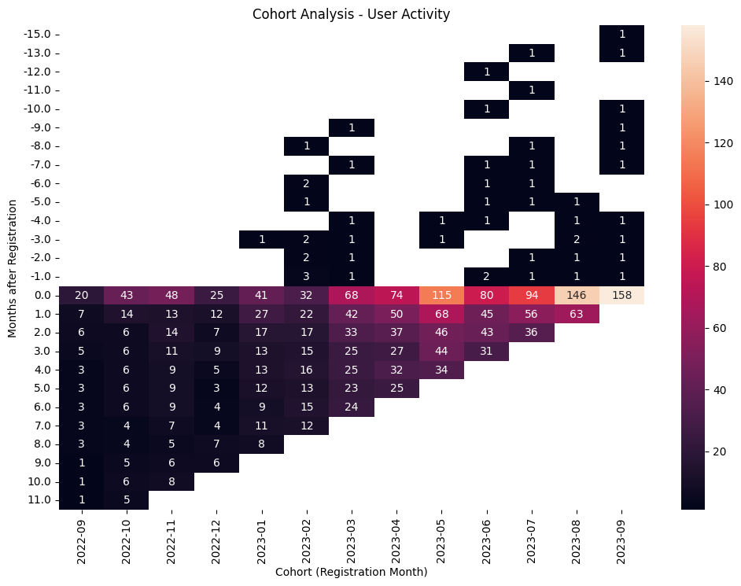

```python
cohort_analysis = activity_with_cohort_df.groupby(['cohort', 'month_diff']).userId.nunique().unstack(0)



plt.figure(figsize=(12, 8))
sns.heatmap(cohort_analysis, annot=True, fmt='g')
plt.title('Cohort Analysis - User Activity')
plt.ylabel('Months after Registration')
plt.xlabel('Cohort (Registration Month)')
plt.show()
```

### 5.3. Average Time Spent by Cohort

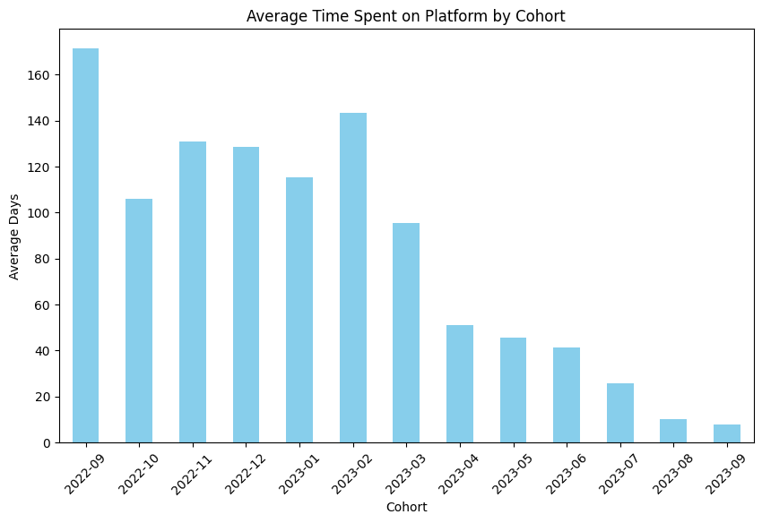

```python
all_activities_df = pd.concat([
    adds_new_client_df[['userId', 'adds_new_client_time']].rename(columns={'adds_new_client_time': 'activity_time'}),
    exports_note_df[['userId', 'exports_note_time']].rename(columns={'exports_note_time': 'activity_time'}),
    signs_notes_df[['userId', 'signs_notes_time']].rename(columns={'signs_notes_time': 'activity_time'}),
    uploads_audio_file_df[['userId', 'uploads_audio_file_time']].rename(columns={'uploads_audio_file_time': 'activity_time'})
])

all_activities_df['activity_time'] = pd.to_datetime(all_activities_df['activity_time'])

all_activities_cohort_df = pd.merge(all_activities_df, new_registration_df[['userId', 'cohort']], on='userId', how='left')

activity_time_stats = all_activities_cohort_df.groupby('userId').agg(first_activity=('activity_time', 'min'), last_activity=('activity_time', 'max'))

activity_time_stats = activity_time_stats.merge(new_registration_df[['userId', 'cohort']], on='userId')

activity_time_stats['time_spent_days'] = (activity_time_stats['last_activity'] - activity_time_stats['first_activity']).dt.days

average_time_spent_by_cohort = activity_time_stats.groupby('cohort')['time_spent_days'].mean()

average_time_spent_by_cohort.plot(kind='bar', figsize=(10,6), color='skyblue')
plt.title('Average Time Spent on Platform by Cohort')
plt.ylabel('Average Days')
plt.xlabel('Cohort')
plt.xticks(rotation=45)
plt.show()
```

### Analysis

The bar chart demonstrates that the first cohorts spend more time on average, which may imply a stronger initial product fit or more engaged early adopters. Monitoring these trends can guide efforts to maintain or enhance user engagement.

### Monthly Active Users (MAU) Trend

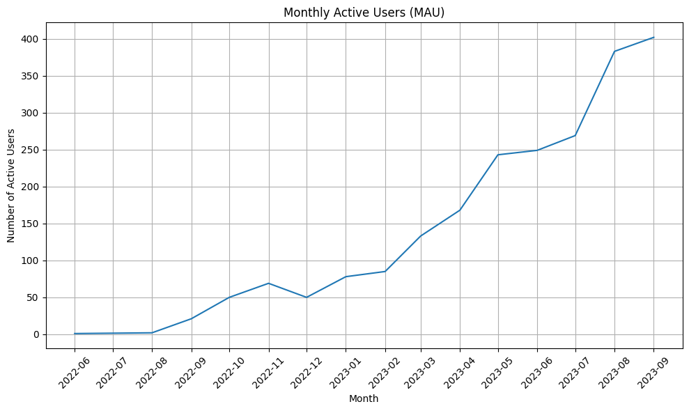

```python
plt.figure(figsize=(10, 6))
plt.plot(mau.index, mau.values)
plt.title('Monthly Active Users (MAU)')
plt.ylabel('Number of Active Users')
plt.xlabel('Month')
plt.xticks(rotation=45)

plt.gca().xaxis.set_major_formatter(mdates.DateFormatter('%Y-%m'))
plt.gca().xaxis.set_major_locator(mdates.MonthLocator(interval=1))

plt.grid(True)
plt.tight_layout()
plt.show()
```

### Code Explanation

This plot provides a straightforward look at the platform's user engagement over time. A rising line suggests increasing user activity and hints at the overall health and growth of the platform. Seasonality and other external factors might influence these trends, and this visualization could prompt a deeper dive into such influences.

### Analysis

The upward trajectory in the MAU chart signifies growth in active users, a positive sign for the platform's adoption and market presence.

### Insights and Recommendations:

- There's an observable decrease in engagement as time progresses post-registration, which suggests the need for more effective retention strategies. Implementing personalized engagement campaigns could address this.
- The average time spent on the platform varies by cohort, indicating that changes to the platform or market dynamics could be impacting user behavior. Continuous monitoring of feature releases and market trends is advisable to understand these shifts better.
- The growth in MAU is a strong indicator of platform health, but it's also essential to match this growth with equally strong retention to sustain long-term success.

Overall, the cohort analysis provides actionable insights that can inform strategies to improve user retention, engagement, and overall platform health. By keeping an eye on these metrics and continuing to iterate on the user experience, the platform can aim to increase the longevity of user engagement across all cohorts.

## 6. Data-driven Recommendations

### Monthly Active Users (MAU) Growth Rate:

- **Rationale**: While raw MAU figures show the scale of active users, the growth rate contextualizes it by indicating the pace at which the active user base is expanding. This metric aligns with the growth strategy and can signal market reach and platform vitality.
- **Usage**: Tracking the MAU Growth Rate is beneficial for understanding market dynamics and the effectiveness of marketing campaigns. It serves as a health check for user acquisition and can also highlight any seasonality in user behavior. This metric, combined with user acquisition costs, can also help in optimizing marketing spend for sustainable growth.

### Implementing the Recommendations:

To implement these recommendations, Mentalyc should set up dashboards that visualize these metrics in real-time, providing a quick glance at the platform's pulse. Additionally, digging deeper into the contributing factors to these metrics should be routine. For instance, segmenting the Week 1 Retention Rate by user demographics or behavior patterns can uncover insights into which user groups are most engaged or at risk of churning.

For product development decisions, these metrics serve as a guiding light. For example, if the Week 1 Retention Rate is below expectations, it may lead to prioritizing features or content that boosts initial engagement. Conversely, if the MAU Growth Rate is stalling, it might indicate the need for new features or improvements to re-engage dormant users or attract a broader audience.

By closely monitoring these metrics, Mentalyc can make informed decisions, prioritize product development efforts, and align their strategies with user needs and business objectives for long-term success.

## 7. Potential Improvement and Recomendations

### User Demographics and Background Information:

- **Improvement**: Collect additional user demographic information, such as age, location, and occupation, during the sign-up process or through initial user surveys.
- **Benefit**: This information would enable more nuanced segmentation and targeted analysis, helping to understand which demographics are most engaged and where there are opportunities for growth.

### Behavioral Data Granularity:

- **Improvement**: Implement more granular event tracking within the platform, capturing detailed user interactions such as time spent on specific features, click-through rates on resources, and the user journey through different platform sections.
- **Benefit**: This can lead to a deeper understanding of how users interact with the platform and which features contribute most to retention and engagement.

### Qualitative Feedback Mechanisms:

- **Improvement**: Regularly solicit qualitative feedback through surveys, suggestion boxes, or direct outreach. Integrate this feedback into the data warehouse alongside quantitative data.
- **Benefit**: Qualitative feedback can provide context to the quantitative data, revealing why certain patterns may be occurring and uncovering user sentiment.

### Cohort Tracking Improvements:

- **Improvement**: Streamline cohort tracking by automatically tagging users based on their registration date and other key events.
- **Benefit**: This would simplify the process of cohort analysis and reduce the chance of errors during data merging and manipulation.

### Technical Data Quality Checks:

- **Improvement**: Implement automated checks for data quality issues such as missing values, duplicates, and inconsistencies across data sources.
- **Benefit**: Ensuring high-quality data will improve the reliability of analyses and reduce time spent cleaning data.

### Unified Customer View:

- **Improvement**: Use a customer data platform (CDP) to integrate data from disparate sources, providing a unified view of the customer journey across all touchpoints.
- **Benefit**: A 360-degree view of the customer journey is invaluable for personalization and understanding the full user experience.

### Enhanced Data Infrastructure:

- **Improvement**: Invest in a scalable and secure data infrastructure that allows for real-time data processing and complex analytical computations.
- **Benefit**: A robust infrastructure will support advanced analytics, real-time decision-making, and machine learning applications.

### Longitudinal Studies:

- **Improvement**: Conduct longitudinal studies to track user behavior and platform interaction over extended periods.
- **Benefit**: Longitudinal data will provide insights into long-term trends and the life cycle of users, informing decisions about user retention strategies and product development.

These improvements require an upfront investment but can significantly enhance the ability to make informed decisions based on data. They can also help in creating a culture of continuous learning and adaptation, which is vital for the growth and success of a platform like Mentalyc.